# Environmental Plastic Waste Analysis

Author

Jade Gehrts

```r
library(httr)
library(tidyjson)
library(jsonlite)
library(tidyverse)
library(glue)
library(purrr)
library(countrycode)
library(scales)
```

## Context

The Environmental Plastic Waste Data comes from the **“Break Free from Plastic”** movement and covers information on plastic use across the world, organized by country, type of plastic, source of plastic, and year (2019 or 2020). The data comes from brand audits and cleanups conducted by volunteers. Some limitations of this dataset are that the countries will not have an equal sampling effort and the data depends on volunteer participation. Additionally, the amount of collected waste does not necessarily tell us how much plastic there is in general. Aside from those, the data is useful to help identify major corporate contributors to plastic pollution in our environment. It can also help inform environmental policy workers and provide corporate accountability.

# Checkpoint 3

Checkpoint 3

Temperature (dataset): https://www.kaggle.com/datasets/palinatx/mean-temperature-for-countries-by-year-2014-2022

GDP (API): https://www.imf.org/external/datamapper/api/help https://api-ninjas.com/api/gdp

Key: 8FzJfy67lKE4OUN74J48zZqI0x2ivVWkBPIRqN0K

https://api.api-ninjas.com/v1/gdp?country=Canada%20;X-Api-Key=RID1ERp0hNnGs3eiSIxGI87z2tT3Y8FDbngGnwlb

Quarto Code:

```r
write_csv(x = gdp, file = "stat431-gdp")
```

```r
gdp <- read_csv("stat431-gdp.csv")
gdp
```

```
# A tibble: 325 × 8
   country  year gdp_growth gdp_nominal gdp_per_capita_nominal   gdp_ppp
   <chr>   <dbl>      <dbl>       <dbl>                  <dbl>     <dbl>
 1 DOM      2019        5.1      89.0                    8595.   215.
 2 DOM      2020       -6.7      78.9                    7554.   210.
 3 USA      2019        2.6   21540.                    65561. 21540.
 4 USA      2020       -2.2   21354.                    64462. 21354.
 5 ZMB      2019        1.4      23.3                    1268.    62.2
 6 ZMB      2020       -2.8      18.1                     958.    60.2
 7 VUT      2019        3.2       0.93                   3187.     0.84
 8 VUT      2020       -5         1.01                   3341.     0.809
 9 TON      2019       -0.2       0.445                  4435.     0.621
10 TON      2020        1.3       0.445                  4439.     0.638
# ℹ 315 more rows
# ℹ 2 more variables: gdp_per_capita_ppp <dbl>, gdp_ppp_share <dbl>
```

Checkpoint 4

# Project Checkpoint 4

```r
plastic_temp_gdp <- read_csv("stat431-meta")
```

```r
plastic_temp_gdp <- plastic_temp_gdp |>
  mutate(continent = countrycode(Country,
                                  origin = "country.name",
                                  destination = "continent"))
```

## RQ #1: How does change in GDP relate to change in the total amount of plastic collected?

Checkpoint 4

# Project Checkpoint 4

```r
plastic_temp_gdp <- read_csv("stat431-meta")
```

```r
plastic_temp_gdp <- plastic_temp_gdp |>
  mutate(continent = countrycode(Country,
                                  origin = "country.name",
                                  destination = "continent"))
```

## RQ #1: How does change in GDP relate to change in the total amount of plastic collected?

```r
changed <- plastic_temp_gdp |>
  group_by(Country, continent, Year) |>
  summarise(grand_total = sum(grand_total, na.rm = TRUE), .groups = "drop") |>
  pivot_wider(names_from = Year, values_from = grand_total) |>
  rename(
    total_2019 = `2019`,
    total_2020 = `2020`
  ) |>
  mutate(change = total_2020 - total_2019) |>
  drop_na(change, continent)
```

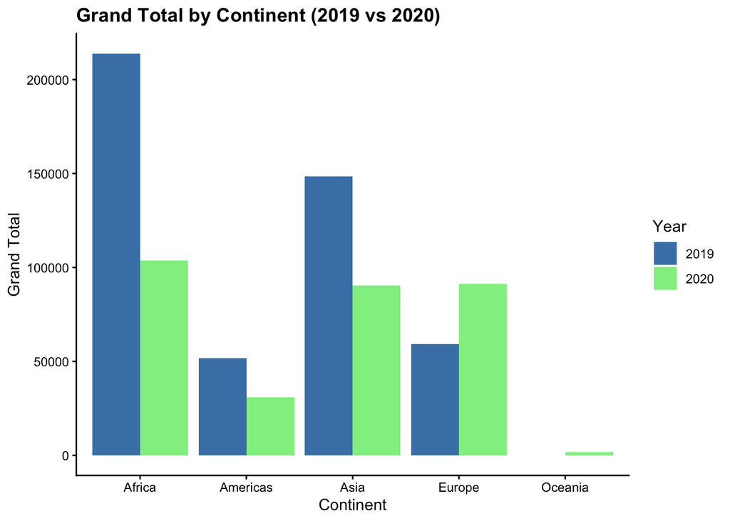

Figure 1.1. Barplot for Change in Grand Total Plastic from 2019-2020, by Continent

```r
continent_year <- plastic_temp_gdp |>
  group_by(continent, Year) |>
  summarise(grand_total = sum(grand_total, na.rm = TRUE), .groups = "drop")

ggplot(continent_year, aes(x = continent, y = grand_total, fill = factor(Year))) +
  geom_col(position = "dodge") +
  labs(
    title = "Grand Total by Continent (2019 vs 2020)",
    x = "Continent",
    y = "Grand Total",
    fill = "Year"
  ) +
  scale_fill_manual(values = c("steelblue", "lightgreen")) +
  theme_classic() +
  theme(plot.title = element_text(face = "bold"))
```

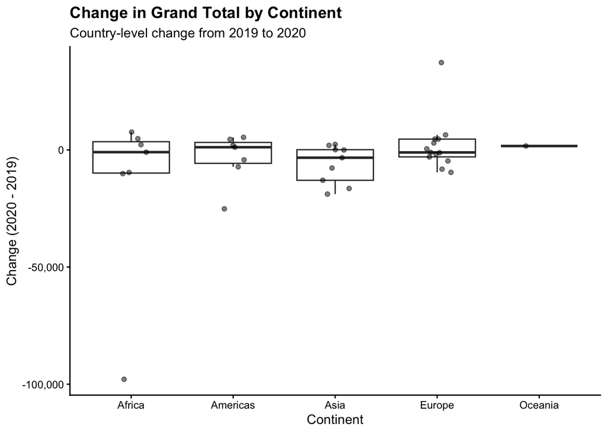

Figure 1.2. Boxplot for Change in Grand Total Plastic from 2019-2020, by Continent

```r
ggplot(changed, aes(x = continent, y = change)) +
  geom_boxplot(outlier.shape = NA) +
  geom_jitter(width = 0.15, alpha = 0.5) +
  scale_y_continuous(labels = comma) +
  labs(
    title = "Change in Grand Total by Continent",
    subtitle = "Country-level change from 2019 to 2020",
    x = "Continent",
    y = "Change (2020 - 2019)"
  ) +
  theme_classic() +
  theme(plot.title = element_text(face = "bold"))
```

We noticed an outlier in Africa that was that was heavily compressing the scale of the boxplot. We identified the outlier to be Nigeria.

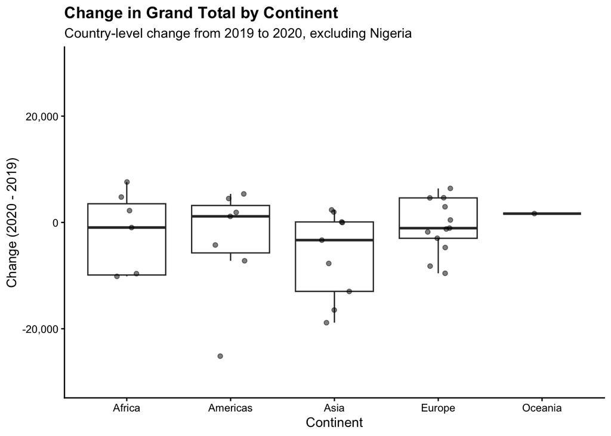

Figure 1.3. Boxplot for Change in Grand Total Plastic from 2019-2020, by Continent (excluding Africa outlier, Nigeria)

```r
ggplot(changed, aes(x = continent, y = change)) +
  geom_boxplot(outlier.shape = NA) +
  geom_jitter(width = 0.15, alpha = 0.5) +
  coord_cartesian(ylim = c(-30000, 30000))+
  scale_y_continuous(labels = comma) +
  labs(
    title = "Change in Grand Total by Continent",
    subtitle = "Country-level change from 2019 to 2020, excluding Nigeria",
    x = "Continent",
    y = "Change (2020 - 2019)"
  ) +
  theme_classic() +
  theme(plot.title = element_text(face = "bold"))
```

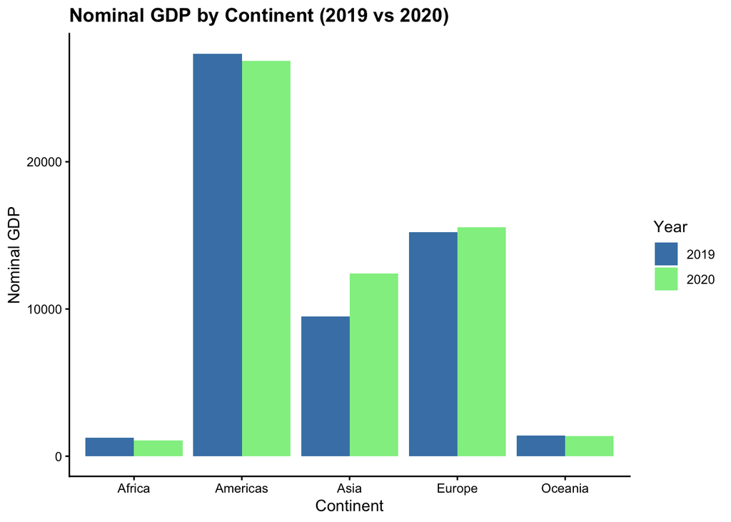

Figure 1.4. Barplot for Change in GDP from 2019-2020, by Continent

```r
continent_year <- plastic_temp_gdp |>
  group_by(continent, Year) |>
  summarise(gdp_nominal = sum(gdp_nominal, na.rm = TRUE), .groups = "drop")

ggplot(continent_year, aes(x = continent, y = gdp_nominal, fill = factor(Year))) +
  geom_col(position = "dodge") +
  labs(
    title = "Nominal GDP by Continent (2019 vs 2020)",
    x = "Continent",
    y = "Nominal GDP",
    fill = "Year"
  ) +
  scale_fill_manual(values = c("steelblue", "lightgreen")) +
  theme_classic() +
  theme(plot.title = element_text(face = "bold"))
```

```r
# Calculating Percent Change in GDP from 2019 to 2020
gdp_changed <- plastic_temp_gdp %>%
  arrange(Country, Year) %>%
  group_by(Country) %>%
  mutate(gdp_pct_change = (gdp_nominal / lag(gdp_nominal) - 1) * 100)
```

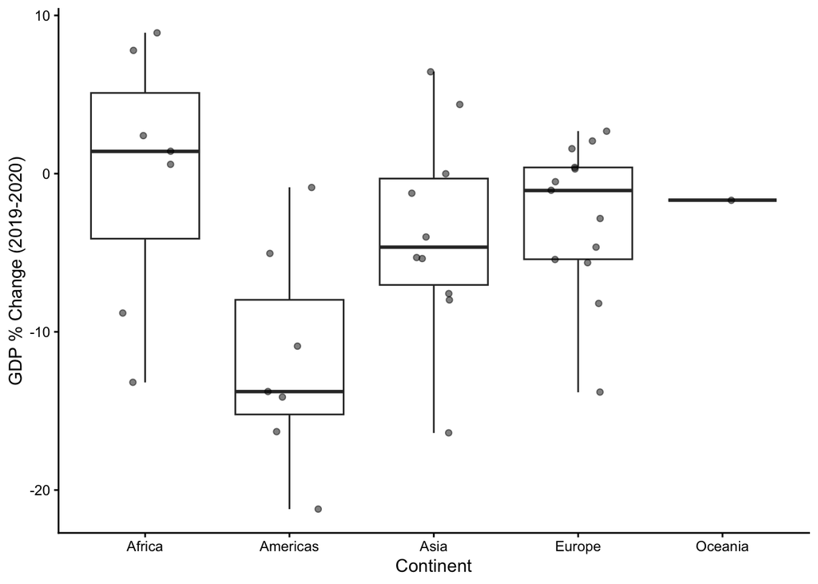

Figure 1.5. Boxplot for Percent Change in GDP from 2019-2020, by Continent

```r
ggplot(gdp_changed, aes(x = continent, y = gdp_pct_change)) +
  geom_boxplot() +
  geom_jitter(width = 0.2, alpha = 0.5) +
  labs(y = "GDP % Change (2019-2020)", x = "Continent") +
  theme_classic() +
  theme(plot.title = element_text(face = "bold"))
```

## RQ #2: Is there a relationship between a country’s mean annual temperature and the total amount of plastic collected?

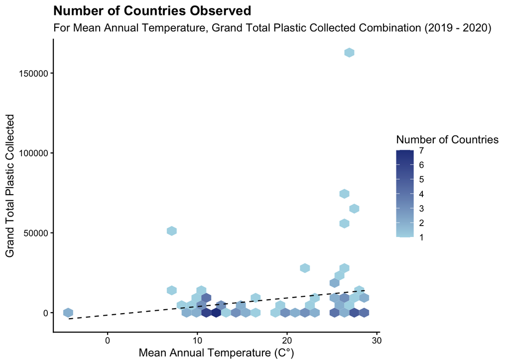

```r
ggplot(data = plastic_temp_gdp) +
  geom_hex(mapping = aes(x = AnnualMeanTemp, y = grand_total)) +
  scale_fill_gradient(low = "lightblue", high = "royalblue4") +
  geom_smooth(aes(x = AnnualMeanTemp, y = grand_total),
              method = "lm", se = FALSE,
              color = "black", linewidth = 0.5, lty = 2) +
  labs(x = "Mean Annual Temperature (C°)",
       y = "Grand Total Plastic Collected",
       fill = "Number of Countries",
       title = "Number of Countries Observed",
       subtitle = "For Mean Annual Temperature, Grand Total Plastic Collected Combination (2019 - 2020)") +
  theme_classic() +
  theme(plot.title = element_text(face = "bold"))
```

```r
# Fitting a linear model
plastic.fit <- lm(grand_total~AnnualMeanTemp, data = plastic_temp_gdp)
summary(plastic.fit)
```

```
Call:
lm(formula = grand_total ~ AnnualMeanTemp, data = plastic_temp_gdp)

Residuals:
   Min     1Q Median     3Q    Max
-13809  -8193  -4250    943 148036

Coefficients:
               Estimate Std. Error t value Pr(>|t|)
(Intercept)     -1535.6     5255.7  -0.292   0.7708
AnnualMeanTemp    536.4      262.9   2.040   0.0442 *
---
Signif. codes:  0 '***' 0.001 '**' 0.01 '*' 0.05 '.' 0.1 ' ' 1

Residual standard error: 20100 on 93 degrees of freedom
Multiple R-squared:  0.04284,   Adjusted R-squared:  0.03255
F-statistic: 4.163 on 1 and 93 DF,  p-value: 0.04416
```

SHRAVANI’S CODE:

```r
changed <- plastic_temp_gdp |>
  group_by(Country, continent, Year) |>
  summarise(grand_total = sum(grand_total, na.rm = TRUE), .groups = "drop") |>
  pivot_wider(names_from = Year, values_from = grand_total) |>
  rename(
    total_2019 = `2019`,
    total_2020 = `2020`
  ) |>
  mutate(change = total_2020 - total_2019) |>
  drop_na(change, continent)
```

Barplot for Continents by Change in Grand Total Plastic from 2019-2020

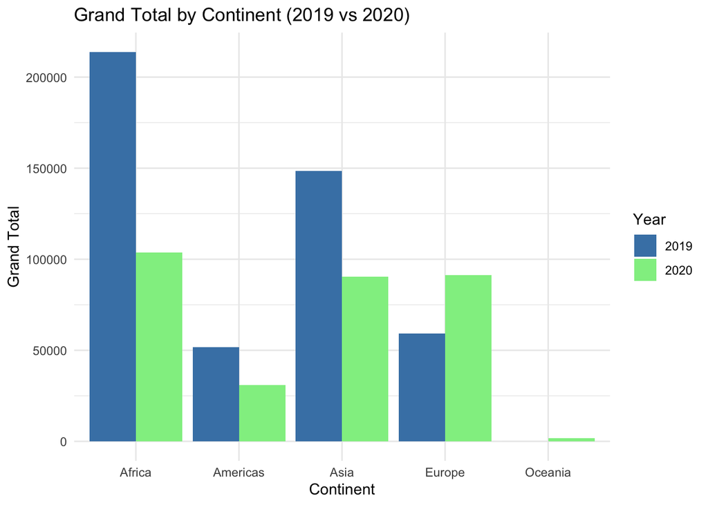

```r
continent_year <- plastic_temp_gdp |>
  group_by(continent, Year) |>
  summarise(grand_total = sum(grand_total, na.rm = TRUE), .groups = "drop")

ggplot(continent_year, aes(x = continent, y = grand_total, fill = factor(Year))) +
  geom_col(position = "dodge") +
  labs(
    title = "Grand Total by Continent (2019 vs 2020)",
    x = "Continent",
    y = "Grand Total",
    fill = "Year"
  ) +
  scale_fill_manual(values = c("steelblue", "lightgreen")) +
  theme_minimal()
```

Boxplot for Continents by Change in Grand Total Plastic from 2019-2020

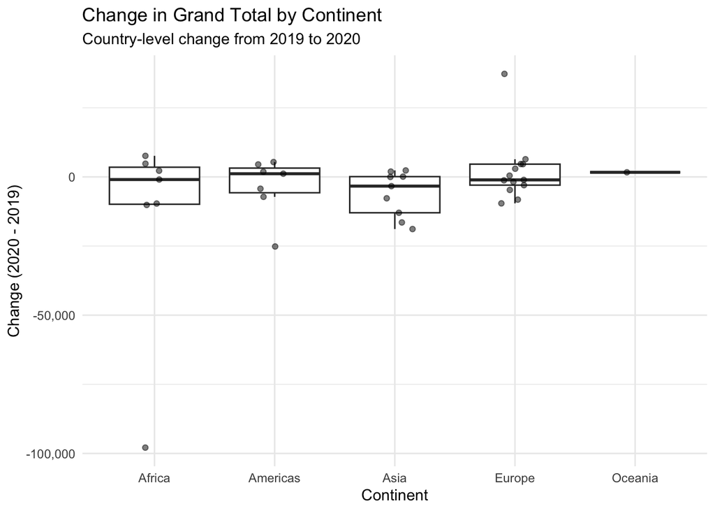

```r
ggplot(changed, aes(x = continent, y = change)) +
  geom_boxplot(outlier.shape = NA) +
  geom_jitter(width = 0.15, alpha = 0.5) +
  scale_y_continuous(labels = comma) +
  labs(
    title = "Change in Grand Total by Continent",
    subtitle = "Country-level change from 2019 to 2020",
    x = "Continent",
    y = "Change (2020 - 2019)"
  ) +
  theme_minimal()
```

Boxplot for Continents by Change in Grand Total Plastic from 2019-2020 (zoomed in without Africa outlier)

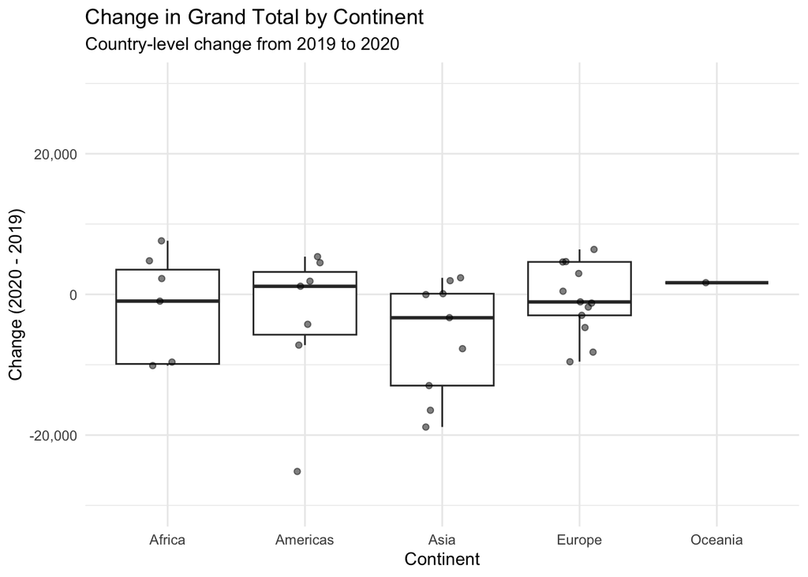

```r
ggplot(changed, aes(x = continent, y = change)) +
  geom_boxplot(outlier.shape = NA) +
  geom_jitter(width = 0.15, alpha = 0.5) +
  coord_cartesian(ylim = c(-30000, 30000))+
  scale_y_continuous(labels = comma) +
  labs(
    title = "Change in Grand Total by Continent",
    subtitle = "Country-level change from 2019 to 2020",
    x = "Continent",
    y = "Change (2020 - 2019)"
  ) +
  theme_minimal()
```

Interesting Change

- what was the outlier in Africa? Nigeria

Barplot for Continents by Change in GDP from 2019-2020

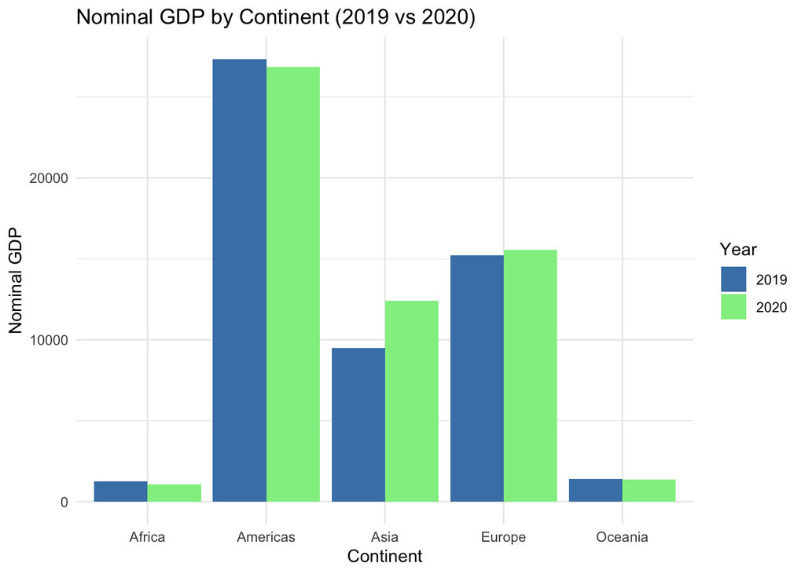

```r
continent_year <- plastic_temp_gdp |>
  group_by(continent, Year) |>
  summarise(gdp_nominal = sum(gdp_nominal, na.rm = TRUE), .groups = "drop")

ggplot(continent_year, aes(x = continent, y = gdp_nominal, fill = factor(Year))) +
  geom_col(position = "dodge") +
  labs(
    title = "Nominal GDP by Continent (2019 vs 2020)",
    x = "Continent",
    y = "Nominal GDP",
    fill = "Year"
  ) +
  scale_fill_manual(values = c("steelblue", "lightgreen")) +
  theme_minimal()
```

Calculating Percent Change in GDP from 2019 to 2020

```r
gdp_changed <- plastic_temp_gdp %>%
  arrange(Country, Year) %>%
  group_by(Country) %>%
  mutate(gdp_pct_change = (gdp_nominal / lag(gdp_nominal) - 1) * 100)
```

Boxplot for Continents by Percent Change in GDP from 2019-2020

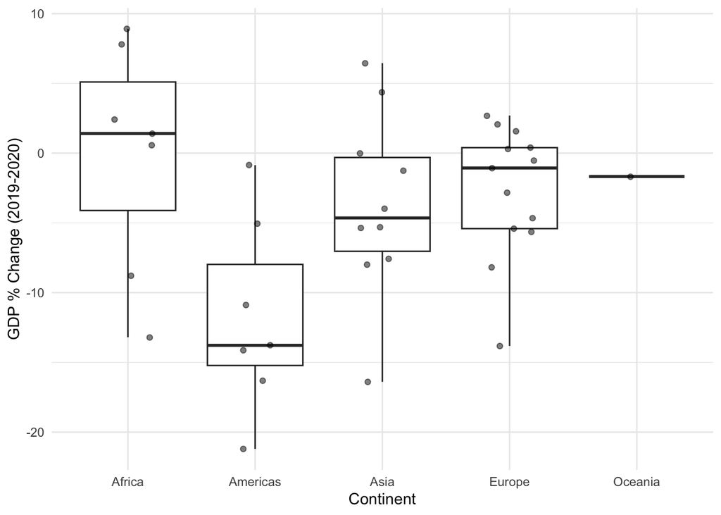

```r
ggplot(gdp_changed, aes(x = continent, y = gdp_pct_change)) +
  geom_boxplot() +
  geom_jitter(width = 0.2, alpha = 0.5) +
  labs(y = "GDP % Change (2019-2020)", x = "Continent") +
  theme_minimal()
```

NOT USED

Table

```r
plastic_temp_gdp |>
  filter(Year == 2019) |>
  group_by(continent) |>
  summarise(total_events = sum(num_events, na.rm = TRUE)) |>
  mutate(percent = total_events / sum(total_events) * 100)
```

```
# A tibble: 5 × 3
  continent total_events percent
  <chr>            <dbl>   <dbl>
1 Africa              60  21.8
2 Americas            59  21.5
3 Asia               108  39.3
4 Europe              47  17.1
5 Oceania              1   0.364
```

```r
plastic_temp_gdp |>
  filter(Year == 2020) |>
  group_by(continent) |>
  summarise(total_events = sum(num_events, na.rm = TRUE)) |>
  mutate(percent = total_events / sum(total_events) * 100)
```

```
# A tibble: 5 × 3
  continent total_events percent
  <chr>            <dbl>   <dbl>
1 Africa              44    8.19
2 Americas           217   40.4
3 Asia               177   33.0
4 Europe              90   16.8
5 Oceania              9    1.68
```

```r
plastic_temp_gdp |>
  filter(Year == 2019) |>
  group_by(continent) |>
  summarise(grand_total = sum(grand_total, na.rm = TRUE), total_gdp = sum(gdp_per_capita_nominal, na.rm = TRUE)) |>
  mutate(percent = grand_total / sum(grand_total) * 100)
```

```
# A tibble: 5 × 4
  continent grand_total total_gdp  percent
  <chr>           <dbl>     <dbl>    <dbl>
1 Africa         213798    23632. 45.2
2 Americas        51852   153943. 11.0
3 Asia           148344   178643. 31.4
4 Europe          59156   528510. 12.5
5 Oceania             6    54391.  0.00127
```

Visualization